# latihan 67

Hakim Zoelva Mahesa

2023-10-14

## Packages

```r
library(ggplot2)
library(tsibble)
library(tseries)
library(MASS)
library(forecast)
library(TSA)
library(TTR)
library(aTSA)
library(graphics)
```

## Data Asli

```r
library(rio)
datasaham <- import("https://raw.githubusercontent.com/hakimzoelvamahesa/mpdw/main/Data/harga%20saham%20samsung%202013-2023.csv")
datasaham<-datasaham$Close
datasaham.ts<-ts(datasaham)
```

### Eksplorasi Data

#### Plot Data Penuh

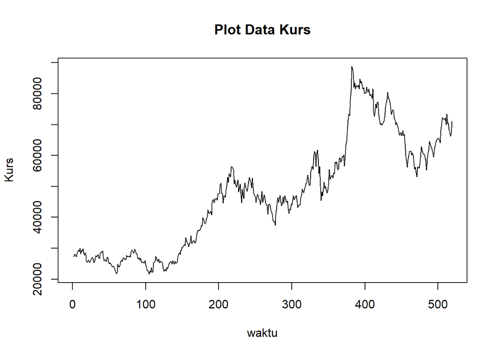

```r
plot.ts(datasaham.ts, lty=1, xlab="waktu", ylab="Kurs", main="Plot Data Kurs")
```

Berdasarkan plot data deret waktu, terlihat bahwa data cenderung memiliki trend yang naik.

#### Plot Data Latih

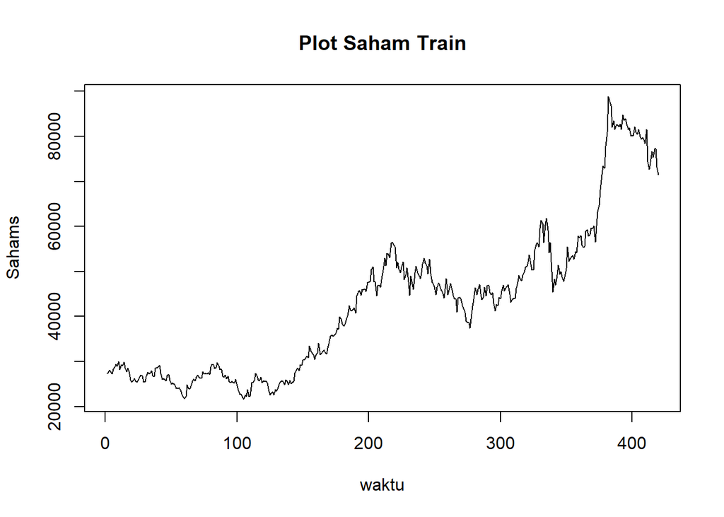

```r
sahamtrain<-datasaham[1:420]
train.ts<-ts(sahamtrain)
plot.ts(train.ts, lty=1, xlab="waktu", ylab="Sahams", main="Plot Saham Train")
```

Berdasarkan plot data deret waktu pada data latih, terlihat bahwa data cenderung memiliki trend yang naik dan cenderung tidak bergerak pada nilai tengah tertentu. Hal ini mengindikasikan bahwa data tidak stasioner dalam rataan.

#### Plot Data Uji

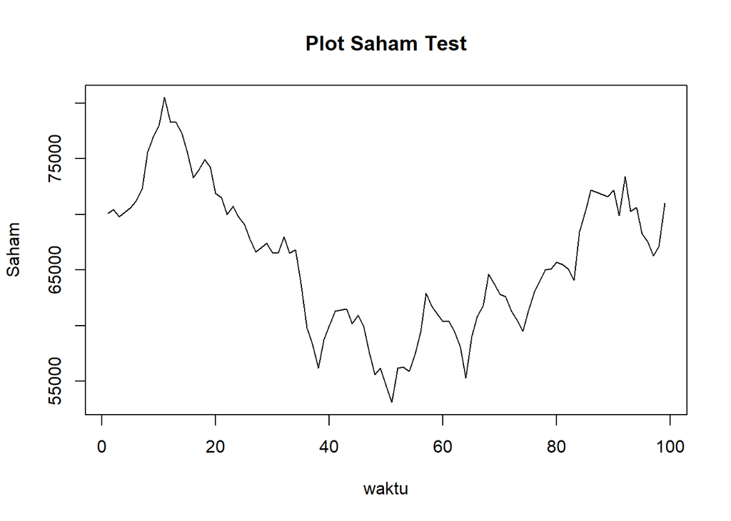

```r
sahamtest<-datasaham[421:519]
test.ts<-ts(sahamtest)
plot.ts(test.ts, lty=1, xlab="waktu", ylab="Saham", main="Plot Saham Test")
```

### Uji Stasioneritas Data

#### Plot ACF

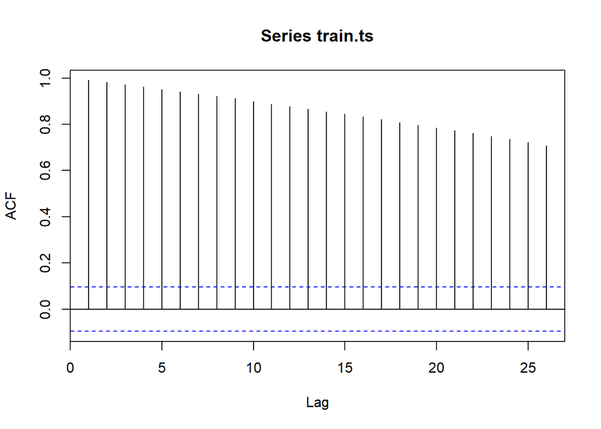

```r
acf(train.ts)
```

Berdasarkan plot ACF, terlihat bahwa plot ACF data menurun secara perlahan (*tails of slowly*). Hal ini juga menjadi indikasi bahwa data tidak stasioner dalam rataan

#### Uji ADF

```r
tseries::adf.test(train.ts)
```

```
##
##  Augmented Dickey-Fuller Test
##
## data:  train.ts
## Dickey-Fuller = -2.6281, Lag order = 7, p-value = 0.3121
## alternative hypothesis: stationary
```

$H_0$ : Data tidak stasioner dalam rataan

$H_1$ : Data stasioner dalam rataan

Berdasarkan uji ADF tersebut, didapat *p-value* sebesar 0.3121 yang lebih besar dari taraf nyata 5% sehingga tak tolak $H_0$ dan menandakan bahwa data tidak stasioner dalam rataan. Hal ini sesuai dengan hasil eksplorasi menggunakan plot time series dan plot ACF, sehingga ketidakstasioneran model kedepannya harus ditangani

#### Plot Box-Cox

```r
index <- seq(1:420)
bc = boxcox(train.ts~index, lambda = seq(-1.5,1.5,by=0.1))
```

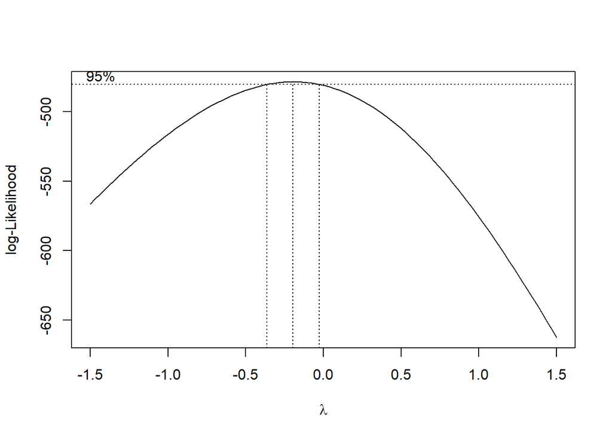

```r
#Nilai Rounded Lambda
lambda <- bc$x[which.max(bc$y)]
lambda
```

```
## [1] -0.1969697
```

```r
#SK
bc$x[bc$y > max(bc$y) - 1/2 * qchisq(.95,1)]
```

```
##  [1] -0.34848485 -0.31818182 -0.28787879 -0.25757576 -0.22727273 -0.19696970
##  [7] -0.16666667 -0.13636364 -0.10606061 -0.07575758 -0.04545455
```

Plot Boxcox menunjukkan nilai *rounded value* ($\lambda$) optimum sebesar **-0.1969697** dan pada selang kepercayaan 95% nilai memiliki batas bawah **-0.34848485** dan batas atas **-0.04545455**. Selang tersebut tidak memuat nilai satu sehingga dapat dikatakan bahwa data tersebut tidak stasioner dalam ragam.

### Penanganan Ketidakstasioneran Data

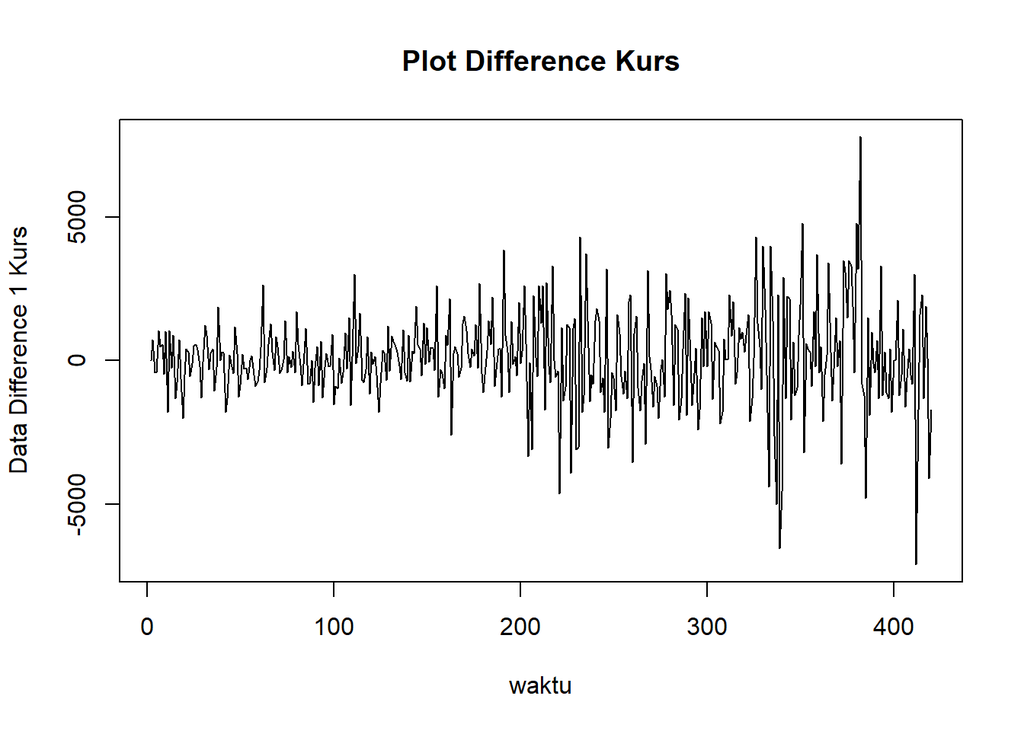

```r
train.diff<-diff(train.ts,differences = 1)
plot.ts(train.diff, lty=1, xlab="waktu", ylab="Data Difference 1 Kurs", main="Plot Difference Kurs")
```

Berdasarkan plot data deret waktu, terlihat bahwa data sudah stasioner dalam rataan ditandai dengan data bergerak pada nilai tengah tertentu (tidak terdapat trend ataupun musiman pada data)

#### Plot ACF

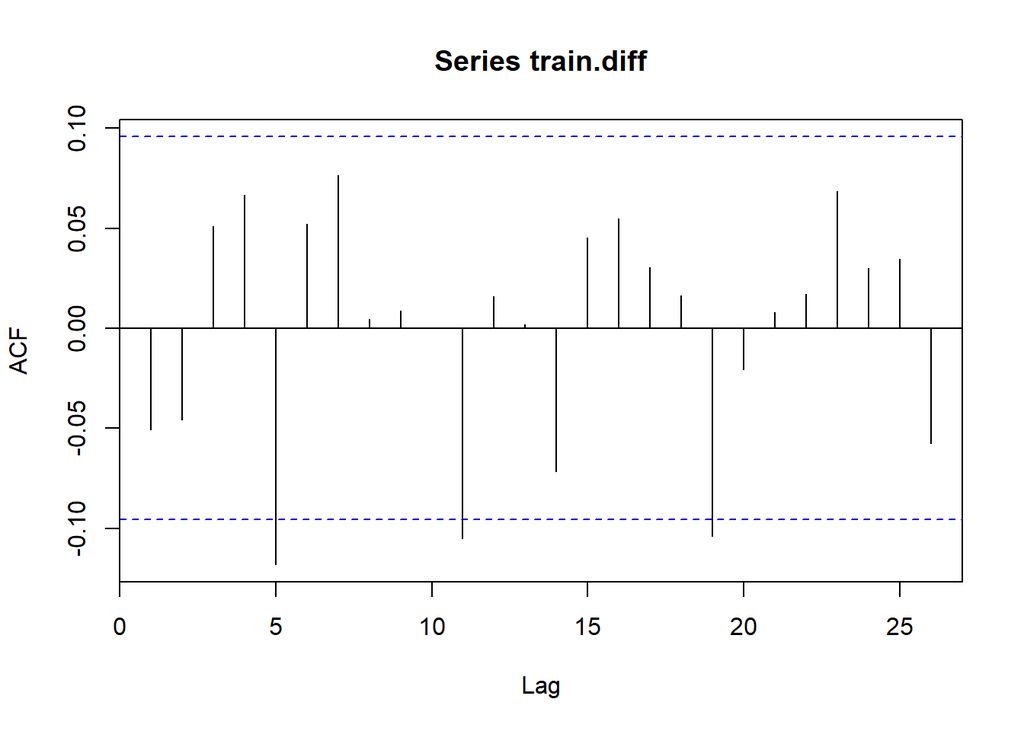

```r
acf(train.diff)
```

Berdasarkan plot tersebut, terlihat bahwa plot ACF cuts off pada lag ke 5. Hal ini menandakan data sudah stasioner dalam rataan dan ketidakstasioneran data telah berhasil tertangani.

#### Uji ADF

```r
tseries::adf.test(train.diff)
```

```
##
##  Augmented Dickey-Fuller Test
##
## data:  train.diff
## Dickey-Fuller = -6.4951, Lag order = 7, p-value = 0.01
## alternative hypothesis: stationary
```

$H_0$ : Data tidak stasioner dalam rataan

$H_1$ : Data stasioner dalam rataan

Berdasarkan uji ADF tersebut, didapat *p-value* sebesar 0.01 yang lebih kecil dari taraf nyata 5% sehingga tolak $H_0$ atau data stasioner dalam rataan. Hal ini sesuai dengan hasil eksplorasi menggunakan plot ACF, sehingga dalam hal ini ketidakstasioneran data sudah berhasil ditangani dan dapat dilanjutkan ke pemodelan

### Identifikasi Model

#### Plot ACF

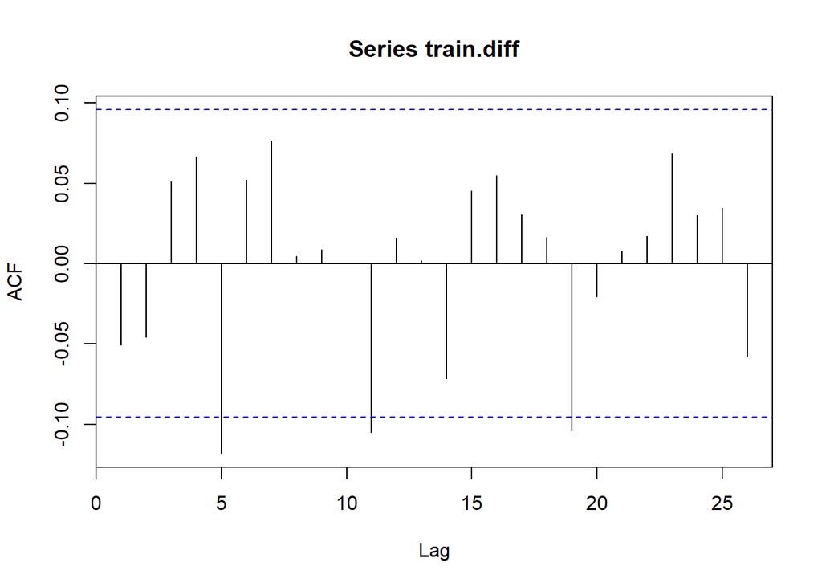

```r
acf(train.diff)
```

Berdasarkan plot tersebut, terlihat bahwa plot ACF cenderung *cuts off* pada lag ke 5, sehingga jika plot PACF dianggap *tails of*, maka model tentatifnya adalah ARIMA(0,1,5).

#### Plot PACF

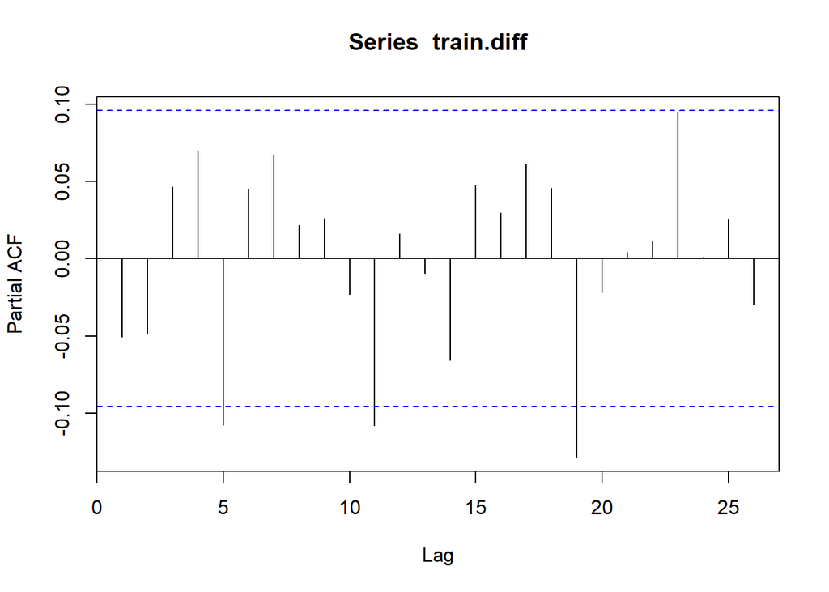

```r
pacf(train.diff)
```

Jika baik plot ACF maupun plot PACF keduanya dianggap tails of, maka model yang terbentuk adalah ARIMA(5,1,5)

#### Plot EACF

```r
eacf(train.diff)
```

```
## AR/MA
##   0 1 2 3 4 5 6 7 8 9 10 11 12 13
## 0 o o o o x o o o o o x  o  o  o
## 1 x o o o o o o o o o x  o  o  o
## 2 x x o o o o o o o o x  o  o  o
## 3 x x x o o o o o o o o  o  o  o
## 4 x x x x o o o o o o o  o  o  o
## 5 x x o x o o o o o o o  o  o  o
## 6 x x x x o x o o o o o  o  o  o
## 7 x x x x o x x o o o o  o  o  o
```

Identifikasi model menggunakan plot EACF dilakukan dengan melihat ujung segitiga pada pola segitiga nol. Dalam hal ini model tentatif yang terbentuk adalah ARIMA(0,1,5), ARIMA(1,1,1), ARIMA(2,1,2), ARIMA(3,1,3), dan ARIMA (4,1,4).

### Pendugaan Parameter Model Tentatif

#### ARIMA(5,1,0)

```r
model1.da=Arima(train.diff, order=c(5,1,0),method="ML")
summary(model1.da) #AIC=7453.91
```

```
## Series: train.diff
## ARIMA(5,1,0)
##
## Coefficients:
##           ar1      ar2      ar3      ar4      ar5
##       -0.8696  -0.7471  -0.5201  -0.2731  -0.2171
## s.e.   0.0478   0.0630   0.0684   0.0630   0.0481
##
## sigma^2 = 3188007:  log likelihood = -3720.96
## AIC=7453.91   AICc=7454.12   BIC=7478.12
##
## Training set error measures:
##                     ME     RMSE      MAE MPE MAPE      MASE        ACF1
## Training set -10.79731 1772.669 1288.555 NaN  Inf 0.7323924 -0.04465824
```

```r
lmtest::coeftest(model1.da) #seluruh parameter signifikan
```

```
##
## z test of coefficients:
##
##      Estimate Std. Error  z value  Pr(>|z|)
## ar1 -0.869562   0.047783 -18.1982 < 2.2e-16 ***
## ar2 -0.747122   0.063019 -11.8556 < 2.2e-16 ***
## ar3 -0.520079   0.068436  -7.5995 2.974e-14 ***
## ar4 -0.273130   0.063044  -4.3324 1.475e-05 ***
## ar5 -0.217121   0.048088  -4.5150 6.330e-06 ***
## ---
## Signif. codes:  0 '***' 0.001 '**' 0.01 '*' 0.05 '.' 0.1 ' ' 1
```

#### ARIMA(0,1,5)

```r
model2.da=Arima(train.diff, order=c(0,1,5),method="ML")
summary(model2.da) #AIC=7402.82
```

```
## Series: train.diff
## ARIMA(0,1,5)
##
## Coefficients:
##           ma1      ma2     ma3     ma4      ma5
##       -1.0391  -0.0012  0.0739  0.0260  -0.0597
## s.e.   0.0512   0.0741  0.0627  0.0794   0.0516
##
## sigma^2 = 2788764:  log likelihood = -3695.41
## AIC=7402.82   AICc=7403.02   BIC=7427.03
##
## Training set error measures:
##                    ME     RMSE     MAE MPE MAPE      MASE         ACF1
## Training set 51.65973 1657.959 1187.91 NaN  Inf 0.6751875 -0.009692341
```

```r
lmtest::coeftest(model2.da) #hanaya parameter ma1 yang signifikan
```

```
##
## z test of coefficients:
##
##       Estimate Std. Error  z value Pr(>|z|)
## ma1 -1.0390825  0.0511696 -20.3067   <2e-16 ***
## ma2 -0.0011647  0.0741212  -0.0157   0.9875
## ma3  0.0739467  0.0627451   1.1785   0.2386
## ma4  0.0260368  0.0794080   0.3279   0.7430
## ma5 -0.0597274  0.0516258  -1.1569   0.2473
## ---
## Signif. codes:  0 '***' 0.001 '**' 0.01 '*' 0.05 '.' 0.1 ' ' 1
```

#### ARIMA(1,1,1)

```r
model3.da=Arima(train.diff, order=c(1,1,1),method="ML")
summary(model3.da) #AIC=7399.85
```

```
## Series: train.diff
## ARIMA(1,1,1)
##
## Coefficients:
##           ar1      ma1
##       -0.0485  -1.0000
## s.e.   0.0489   0.0093
##
## sigma^2 = 2788136:  log likelihood = -3696.93
## AIC=7399.85   AICc=7399.91   BIC=7411.96
##
## Training set error measures:
##                    ME     RMSE      MAE MPE MAPE      MASE         ACF1
## Training set 55.03379 1663.783 1199.318 NaN  Inf 0.6816717 -0.005820374
```

```r
lmtest::coeftest(model3.da) #seluruh parameter signifikan
```

```
##
## z test of coefficients:
##
##       Estimate Std. Error   z value Pr(>|z|)
## ar1 -0.0484628  0.0489144   -0.9908   0.3218
## ma1 -0.9999999  0.0092721 -107.8500   <2e-16 ***
## ---
## Signif. codes:  0 '***' 0.001 '**' 0.01 '*' 0.05 '.' 0.1 ' ' 1
```

#### ARIMA(2,1,2)

```r
model4.da=Arima(train.diff, order=c(2,1,2),method="ML")
summary(model4.da) #AIC=7402.73
```

```
## Series: train.diff
## ARIMA(2,1,2)
##
## Coefficients:
##           ar1      ar2      ma1      ma2
##       -0.2344  -0.0602  -0.8165  -0.1835
## s.e.   0.3776   0.0513   0.3758   0.3757
##
## sigma^2 = 2793495:  log likelihood = -3696.36
## AIC=7402.73   AICc=7402.88   BIC=7422.91
##
## Training set error measures:
##                    ME     RMSE      MAE MPE MAPE      MASE         ACF1
## Training set 58.39582 1661.373 1192.583 NaN  Inf 0.6778437 -0.002433969
```

```r
lmtest::coeftest(model4.da) #hanya parameter ma 1 yang signifikan
```

```
##
## z test of coefficients:
##
##      Estimate Std. Error z value Pr(>|z|)
## ar1 -0.234445   0.377616 -0.6209  0.53469
## ar2 -0.060152   0.051288 -1.1728  0.24087
## ma1 -0.816526   0.375848 -2.1725  0.02982 *
## ma2 -0.183473   0.375718 -0.4883  0.62532
## ---
## Signif. codes:  0 '***' 0.001 '**' 0.01 '*' 0.05 '.' 0.1 ' ' 1
```

#### ARIMA(3,1,3)

```r
model5.da=Arima(train.diff, order=c(3,1,3),method="ML")
summary(model5.da) #AIC=7390.98
```

```
## Series: train.diff
## ARIMA(3,1,3)
##
## Coefficients:
##           ar1      ar2      ar3     ma1      ma2      ma3
##       -1.1783  -1.0354  -0.1095  0.1474  -0.2062  -0.9411
## s.e.   0.0601   0.0592   0.0508  0.0386   0.0336   0.0368
##
## sigma^2 = 2699294:  log likelihood = -3688.49
## AIC=7390.98   AICc=7391.25   BIC=7419.22
##
## Training set error measures:
##                    ME     RMSE      MAE MPE MAPE      MASE          ACF1
## Training set 57.62613 1629.171 1164.715 NaN  Inf 0.6620036 -0.0003303249
```

```r
lmtest::coeftest(model5.da) #seluruh parameter signifikan
```

```
##
## z test of coefficients:
##
##      Estimate Std. Error  z value  Pr(>|z|)
## ar1 -1.178298   0.060062 -19.6180 < 2.2e-16 ***
## ar2 -1.035399   0.059207 -17.4877 < 2.2e-16 ***
## ar3 -0.109528   0.050841  -2.1543 0.0312156 *
## ma1  0.147351   0.038596   3.8178 0.0001347 ***
## ma2 -0.206237   0.033552  -6.1468 7.905e-10 ***
## ma3 -0.941100   0.036780 -25.5876 < 2.2e-16 ***
## ---
## Signif. codes:  0 '***' 0.001 '**' 0.01 '*' 0.05 '.' 0.1 ' ' 1
```

#### ARIMA(4,1,4)

```r
model6.da=Arima(train.diff, order=c(4,1,4),method="ML")
summary(model6.da) #AIC=7394.16
```

```
## Series: train.diff
## ARIMA(4,1,4)
##
## Coefficients:
##           ar1      ar2     ar3     ar4      ma1      ma2      ma3     ma4
##       -0.7368  -0.4820  0.3817  0.0898  -0.2908  -0.2700  -0.8421  0.4029
## s.e.   1.3400   1.5708  1.3810  0.1477   1.3440   0.2011   0.2785  1.2662
##
## sigma^2 = 2708132:  log likelihood = -3688.08
## AIC=7394.16   AICc=7394.6   BIC=7430.48
##
## Training set error measures:
##                    ME    RMSE      MAE MPE MAPE      MASE         ACF1
## Training set 52.33944 1627.87 1168.217 NaN  Inf 0.6639946 -0.004204739
```

```r
lmtest::coeftest(model6.da) #hanaya parameter ma 3 yag signifikan
```

```
##
## z test of coefficients:
##
##      Estimate Std. Error z value Pr(>|z|)
## ar1 -0.736812   1.339987 -0.5499 0.582412
## ar2 -0.481998   1.570783 -0.3069 0.758956
## ar3  0.381718   1.380981  0.2764 0.782233
## ar4  0.089823   0.147675  0.6083 0.543022
## ma1 -0.290807   1.343986 -0.2164 0.828695
## ma2 -0.270012   0.201082 -1.3428 0.179339
## ma3 -0.842107   0.278473 -3.0240 0.002494 **
## ma4  0.402945   1.266206  0.3182 0.750310
## ---
## Signif. codes:  0 '***' 0.001 '**' 0.01 '*' 0.05 '.' 0.1 ' ' 1
```

Berdasarkan pendugaan parameter di atas, nilai AIC terkecil dimiliki oleh model ARIMA(3,1,3) dan parameter model ARIMA(3,1,3) juga seluruhnya signifikan sehingga model yang dipilih adalah model ARIMA(3,1,3).

### Analisis Sisaan

Model terbaik hasil identifikasi kemudian dicek asumsi sisaannya. Sisaan model ARIMA harus memenuhi asumsi normalitas, kebebasan sisaan, dan kehomogenan ragam. Diagnostik model dilakukan secara eksplorasi dan uji formal.

#### Eksplorasi Sisaan

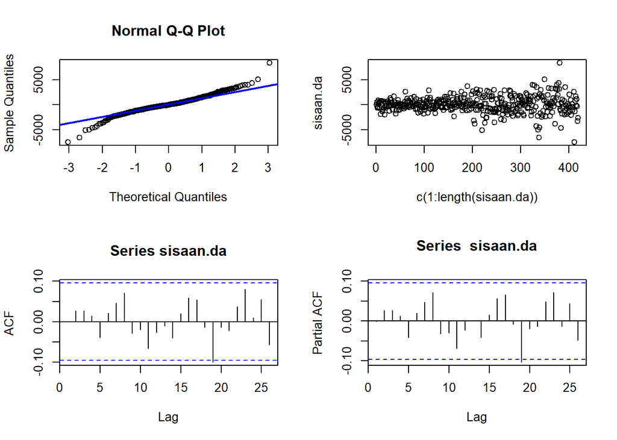

```r
#Eksplorasi
sisaan.da <- model5.da$residuals
par(mfrow=c(2,2))
qqnorm(sisaan.da)
qqline(sisaan.da, col = "blue", lwd = 2)
plot(c(1:length(sisaan.da)),sisaan.da)
acf(sisaan.da)
pacf(sisaan.da)
```

```r
par(mfrow = c(1,1))
```

Berdasarkan plot kuantil-kuantil normal, secara eksplorasi ditunjukkan sisaan tidak menyebar normal ditandai dengan titik titik yang cenderung tidak mengikuti garis $45^{\circ}$. Kemudian dapat dilihat juga lebar pita sisaan yang cenderung tidak sama menandakan bahwa sisaan memiliki ragam yang heterogen. Plot ACF dan PACF sisaan ARIMA(3,1,3) juga tidak signifikan pada 20 lag awal yang menandakan saling bebas. Kondisi ini akan diuji lebih lanjut dengan uji formal.

#### Uji Formal

```r
#1) Sisaan Menyebar Normal
ks.test(sisaan.da,"pnorm")  #tak tolak H0 > sisaan menyebar normal
```

```
##
##  Asymptotic one-sample Kolmogorov-Smirnov test
##
## data:  sisaan.da
## D = 0.50597, p-value < 2.2e-16
## alternative hypothesis: two-sided
```

Selain dengan eksplorasi, asumsi tersebut dapat diuji menggunakan uji formal. Pada tahapan ini uji formal yang digunakan untuk normalitas adalah uji Kolmogorov-Smirnov (KS). Hipotesis pada uji KS adalah sebagai berikut.

$H_0$ : Sisaan menyebar normal

$H_1$ : Sisaan tidak menyebar normal

Berdasarkan uji KS tersebut, didapat *p-value* sebesar 2.2e-16 yang kurang dari taraf nyata 5% sehingga tolak $H_0$ dan menandakan bahwa sisaan tidak menyebar normal. Hal ini sesuai dengan hasil eksplorasi menggunakan plot kuantil-kuantil normal.

```r
#2) Sisaan saling bebas/tidak ada autokorelasi
Box.test(sisaan.da, type = "Ljung")  #tak tolak H0 > sisaan saling bebas
```

```
##
##  Box-Ljung test
##
## data:  sisaan.da
## X-squared = 4.6047e-05, df = 1, p-value = 0.9946
```

Selanjutnya akan dilakukan uji formal untuk kebebasan sisaan menggunakan uji Ljung-Box. Hipotesis yang digunakan adalah sebagai berikut.

$H_0$ : Sisaan saling bebas

$H_1$ : Sisaan tidak tidak saling bebas

```r
#3) Sisaan homogen
Box.test((sisaan.da)^2, type = "Ljung")  #tak tolak H0 > sisaan homogen
```

```
##
##  Box-Ljung test
##
## data:  (sisaan.da)^2
## X-squared = 8.0617, df = 1, p-value = 0.004521
```

Hipotesis yang digunakan untuk uji kehomogenan ragam adalah sebagai berikut.

$H_0$ : Ragam sisaan homogen

$H_1$ : Ragam sisaan tidak homogen

```r
#4) Nilai tengah sisaan sama dengan nol
t.test(sisaan.da, mu = 0, conf.level = 0.95)  #tak tolak h0 > nilai tengah sisaan sama dengan 0
```

```
##
##  One Sample t-test
##
## data:  sisaan.da
## t = 0.72362, df = 418, p-value = 0.4697
## alternative hypothesis: true mean is not equal to 0
## 95 percent confidence interval:
##  -98.90983 214.16208
## sample estimates:
## mean of x
##  57.62613
```

Terakhir, dengan uji-t, akan dicek apakah nilai tengah sisaan sama dengan nol. Hipotesis yang diujikan sebagai berikut.

$H_0$ : nilai tengah sisaan sama dengan 0

$H_1$ : nilai tengah sisaan tidak sama dengan 0

### Peramalan

Peramalan dilakukan menggunakan fungsi `forecast()` . Contoh peramalan berikut ini dilakukan untuk 98 hari ke depan.

```r
#---FORECAST---#
ramalan.da <- forecast::forecast(model5.da, h = 98)
ramalan.da
```

```
##     Point Forecast     Lo 80    Hi 80     Lo 95    Hi 95
## 421   563.78746960 -1544.249 2671.824 -2660.176 3787.751
## 422  -545.80841021 -2654.699 1563.082 -3771.078 2679.461
## 423   596.31257350 -1515.817 2708.442 -2633.911 3826.536
## 424   151.48079435 -1960.698 2263.660 -3078.818 3381.780
## 425  -385.39427738 -2503.703 1732.915 -3625.068 2854.279
## 426   582.68932715 -1540.628 2706.007 -2664.644 3830.023
## 427    46.59935050 -2076.829 2170.028 -3200.904 3294.103
## 428  -265.27692804 -2392.243 1861.689 -3518.191 2987.637
## 429   551.24152540 -1580.068 2682.551 -2708.315 3810.798
## 430   -29.22773208 -2161.037 2102.581 -3289.548 3231.093
## 431  -156.52514762 -2290.158 1977.108 -3419.635 3106.585
## 432   505.05517775 -1632.039 2642.150 -2763.349 3773.459
## 433   -79.10276664 -2217.102 2058.896 -3348.890 3190.685
## 434   -61.84750154 -2200.638 2076.943 -3332.845 3209.150
```

[output cut: 84 more lines]

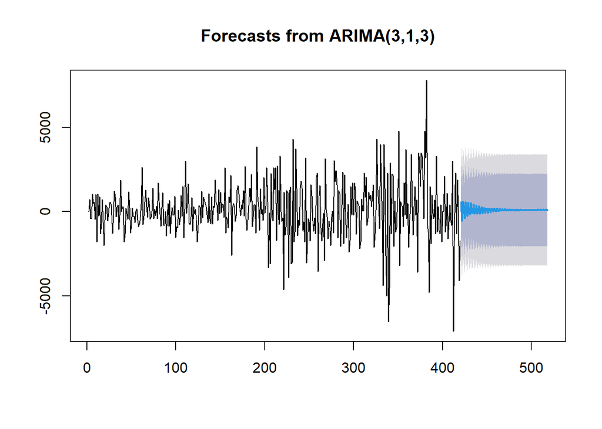

```r
data.ramalan.da <- ramalan.da$mean
plot(ramalan.da)
```

Berdasarkan hasil plot ramalan di atas, dapat dilihat bahwa ramalan ARIMA(3,1,3) cenderung stabil hingga akhir periode. Selanjutnya, dapat dicari nilai akurasi antara hasil ramalan dengan data uji sebagai berikut.

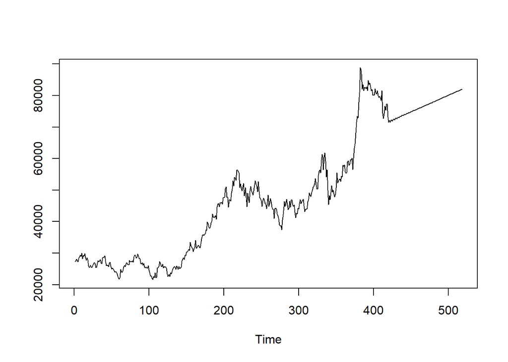

```r
pt_1 <- train.ts[420] #nilai akhir data latih
hasil.forc.Diff <- data.ramalan.da
hasil <- diffinv(hasil.forc.Diff, differences = 1) + pt_1
#has.1 sama hasilnta dengan: cumsum(c(pt_1,hasil.forc.Diff))
ts.plot(train.ts,hasil)
```

```r
perbandingan.da<-matrix(data=c(head(test.ts, n=98), hasil[-1]),
                     nrow = 98, ncol = 2)
colnames(perbandingan.da)<-c("Aktual","Hasil Forecast")
perbandingan.da
```

```
##       Aktual Hasil Forecast
##  [1,]  70100       72063.79
##  [2,]  70400       71517.98
##  [3,]  69800       72114.29
##  [4,]  70200       72265.77
##  [5,]  70600       71880.38
##  [6,]  71200       72463.07
##  [7,]  72300       72509.67
##  [8,]  75600       72244.39
##  [9,]  76900       72795.63
## [10,]  78000       72766.40
## [11,]  80500       72609.88
## [12,]  78300       73114.93
## [13,]  78300       73035.83
## [14,]  77300       72973.98
```

[output cut: 84 more lines]

```r
accuracy(ts(hasil[-1]), head(test.ts, n=98))
```

```
##              ME     RMSE      MAE       MPE     MAPE      ACF1 Theil's U
## Test set -11086 13607.65 11903.64 -18.08579 19.13687 0.9698622  8.781861
```

Diperoleh nilai MAPE sebesar 19.13687. Model ini dikategorikan sebagai model yang kurang baik karena nilai MAPE > 10.